# Risk Factor Analysis

## Outcome Variable

**Outcome Variable:** ever_swasted

## Predictor Variables

**Intervention Variable:** mbmi

**Adjustment Set:**

- arm
- W_mage
- meducyrs
- feducyrs
- hhwealth_quart
- W_nchldlt5
- brthmon
- W_parity
- delta_W_mage
- delta_meducyrs
- delta_feducyrs
- delta_hhwealth_quart
- delta_W_nchldlt5
- delta_brthmon
- delta_W_parity

## Stratifying Variables

The analysis was stratified on these variable(s):

- agecat
- studyid
- country

## Data Summary

| agecat | studyid | country | mbmi | ever_swasted | n_cell | n |
| --- | --- | --- | --- | --- | --- | --- |
| 0-24 months | iLiNS-Zinc | BURKINA FASO | Normal weight | 0 | 2647 | 3217 |
| 0-24 months | iLiNS-Zinc | BURKINA FASO | Normal weight | 1 | 116 | 3217 |
| 0-24 months | iLiNS-Zinc | BURKINA FASO | Underweight | 0 | 416 | 3217 |
| 0-24 months | iLiNS-Zinc | BURKINA FASO | Underweight | 1 | 38 | 3217 |
| 0-24 months | JiVitA-3 | BANGLADESH | Normal weight | 0 | 15561 | 26836 |
| 0-24 months | JiVitA-3 | BANGLADESH | Normal weight | 1 | 999 | 26836 |
| 0-24 months | JiVitA-3 | BANGLADESH | Underweight | 0 | 9638 | 26836 |
| 0-24 months | JiVitA-3 | BANGLADESH | Underweight | 1 | 638 | 26836 |
| 0-24 months | LCNI-5 | MALAWI | Normal weight | 0 | 686 | 837 |
| 0-24 months | LCNI-5 | MALAWI | Normal weight | 1 | 6 | 837 |
| 0-24 months | LCNI-5 | MALAWI | Underweight | 0 | 143 | 837 |
| 0-24 months | LCNI-5 | MALAWI | Underweight | 1 | 2 | 837 |
| 0-24 months | MAL-ED | BANGLADESH | Normal weight | 0 | 209 | 254 |
| 0-24 months | MAL-ED | BANGLADESH | Normal weight | 1 | 13 | 254 |
| 0-24 months | MAL-ED | BANGLADESH | Underweight | 0 | 24 | 254 |
| 0-24 months | MAL-ED | BANGLADESH | Underweight | 1 | 8 | 254 |
| 0-24 months | MAL-ED | BRAZIL | Normal weight | 0 | 207 | 221 |
| 0-24 months | MAL-ED | BRAZIL | Normal weight | 1 | 4 | 221 |
| 0-24 months | MAL-ED | BRAZIL | Underweight | 0 | 10 | 221 |
| 0-24 months | MAL-ED | BRAZIL | Underweight | 1 | 0 | 221 |
| 0-24 months | MAL-ED | INDIA | Normal weight | 0 | 175 | 242 |
| 0-24 months | MAL-ED | INDIA | Normal weight | 1 | 18 | 242 |
| 0-24 months | MAL-ED | INDIA | Underweight | 0 | 41 | 242 |
| 0-24 months | MAL-ED | INDIA | Underweight | 1 | 8 | 242 |
| 0-24 months | MAL-ED | NEPAL | Normal weight | 0 | 229 | 238 |
| 0-24 months | MAL-ED | NEPAL | Normal weight | 1 | 9 | 238 |
| 0-24 months | MAL-ED | NEPAL | Underweight | 0 | 0 | 238 |
| 0-24 months | MAL-ED | NEPAL | Underweight | 1 | 0 | 238 |
| 0-24 months | MAL-ED | PERU | Normal weight | 0 | 281 | 290 |
| 0-24 months | MAL-ED | PERU | Normal weight | 1 | 4 | 290 |
| 0-24 months | MAL-ED | PERU | Underweight | 0 | 5 | 290 |
| 0-24 months | MAL-ED | PERU | Underweight | 1 | 0 | 290 |
| 0-24 months | MAL-ED | SOUTH AFRICA | Normal weight | 0 | 247 | 270 |
| 0-24 months | MAL-ED | SOUTH AFRICA | Normal weight | 1 | 15 | 270 |
| 0-24 months | MAL-ED | SOUTH AFRICA | Underweight | 0 | 8 | 270 |
| 0-24 months | MAL-ED | SOUTH AFRICA | Underweight | 1 | 0 | 270 |
| 0-24 months | MAL-ED | TANZANIA, UNITED REPUBLIC OF | Normal weight | 0 | 234 | 256 |
| 0-24 months | MAL-ED | TANZANIA, UNITED REPUBLIC OF | Normal weight | 1 | 8 | 256 |
| 0-24 months | MAL-ED | TANZANIA, UNITED REPUBLIC OF | Underweight | 0 | 13 | 256 |
| 0-24 months | MAL-ED | TANZANIA, UNITED REPUBLIC OF | Underweight | 1 | 1 | 256 |
| 0-24 months | NIH-Birth | BANGLADESH | Normal weight | 0 | 448 | 624 |
| 0-24 months | NIH-Birth | BANGLADESH | Normal weight | 1 | 72 | 624 |
| 0-24 months | NIH-Birth | BANGLADESH | Underweight | 0 | 77 | 624 |
| 0-24 months | NIH-Birth | BANGLADESH | Underweight | 1 | 27 | 624 |
| 0-24 months | NIH-Crypto | BANGLADESH | Normal weight | 0 | 632 | 755 |
| 0-24 months | NIH-Crypto | BANGLADESH | Normal weight | 1 | 55 | 755 |
| 0-24 months | NIH-Crypto | BANGLADESH | Underweight | 0 | 57 | 755 |
| 0-24 months | NIH-Crypto | BANGLADESH | Underweight | 1 | 11 | 755 |
| 0-24 months | PROBIT | BELARUS | Normal weight | 0 | 12054 | 13728 |
| 0-24 months | PROBIT | BELARUS | Normal weight | 1 | 1151 | 13728 |
| 0-24 months | PROBIT | BELARUS | Underweight | 0 | 469 | 13728 |
| 0-24 months | PROBIT | BELARUS | Underweight | 1 | 54 | 13728 |
| 0-24 months | PROVIDE | BANGLADESH | Normal weight | 0 | 512 | 669 |
| 0-24 months | PROVIDE | BANGLADESH | Normal weight | 1 | 30 | 669 |
| 0-24 months | PROVIDE | BANGLADESH | Underweight | 0 | 116 | 669 |
| 0-24 months | PROVIDE | BANGLADESH | Underweight | 1 | 11 | 669 |
| 0-24 months | SAS-CompFeed | INDIA | Normal weight | 0 | 899 | 1390 |
| 0-24 months | SAS-CompFeed | INDIA | Normal weight | 1 | 120 | 1390 |
| 0-24 months | SAS-CompFeed | INDIA | Underweight | 0 | 288 | 1390 |
| 0-24 months | SAS-CompFeed | INDIA | Underweight | 1 | 83 | 1390 |
| 0-24 months | TanzaniaChild2 | TANZANIA, UNITED REPUBLIC OF | Normal weight | 0 | 2155 | 2345 |
| 0-24 months | TanzaniaChild2 | TANZANIA, UNITED REPUBLIC OF | Normal weight | 1 | 152 | 2345 |
| 0-24 months | TanzaniaChild2 | TANZANIA, UNITED REPUBLIC OF | Underweight | 0 | 34 | 2345 |
| 0-24 months | TanzaniaChild2 | TANZANIA, UNITED REPUBLIC OF | Underweight | 1 | 4 | 2345 |
| 0-24 months | ZVITAMBO | ZIMBABWE | Normal weight | 0 | 8415 | 9797 |
| 0-24 months | ZVITAMBO | ZIMBABWE | Normal weight | 1 | 866 | 9797 |
| 0-24 months | ZVITAMBO | ZIMBABWE | Underweight | 0 | 437 | 9797 |
| 0-24 months | ZVITAMBO | ZIMBABWE | Underweight | 1 | 79 | 9797 |

The following strata were considered:

- agecat: 0-24 months, studyid: iLiNS-Zinc, country: BURKINA FASO
- agecat: 0-24 months, studyid: JiVitA-3, country: BANGLADESH
- agecat: 0-24 months, studyid: LCNI-5, country: MALAWI
- agecat: 0-24 months, studyid: MAL-ED, country: BANGLADESH
- agecat: 0-24 months, studyid: MAL-ED, country: BRAZIL
- agecat: 0-24 months, studyid: MAL-ED, country: INDIA
- agecat: 0-24 months, studyid: MAL-ED, country: NEPAL
- agecat: 0-24 months, studyid: MAL-ED, country: PERU
- agecat: 0-24 months, studyid: MAL-ED, country: SOUTH AFRICA
- agecat: 0-24 months, studyid: MAL-ED, country: TANZANIA, UNITED REPUBLIC OF
- agecat: 0-24 months, studyid: NIH-Birth, country: BANGLADESH
- agecat: 0-24 months, studyid: NIH-Crypto, country: BANGLADESH
- agecat: 0-24 months, studyid: PROBIT, country: BELARUS
- agecat: 0-24 months, studyid: PROVIDE, country: BANGLADESH
- agecat: 0-24 months, studyid: SAS-CompFeed, country: INDIA
- agecat: 0-24 months, studyid: TanzaniaChild2, country: TANZANIA, UNITED REPUBLIC OF
- agecat: 0-24 months, studyid: ZVITAMBO, country: ZIMBABWE

### Dropped Strata

Some strata were dropped due to rare outcomes:

- agecat: 0-24 months, studyid: LCNI-5, country: MALAWI
- agecat: 0-24 months, studyid: MAL-ED, country: BRAZIL
- agecat: 0-24 months, studyid: MAL-ED, country: NEPAL
- agecat: 0-24 months, studyid: MAL-ED, country: PERU
- agecat: 0-24 months, studyid: MAL-ED, country: SOUTH AFRICA
- agecat: 0-24 months, studyid: MAL-ED, country: TANZANIA, UNITED REPUBLIC OF
- agecat: 0-24 months, studyid: TanzaniaChild2, country: TANZANIA, UNITED REPUBLIC OF

## Methods Detail

We're interested in the causal parameters $E[Y_a]$ for all values of $a \in \mathcal{A}$. These parameters represent the mean outcome if, possibly contrary to fact, we intervened to set all units to have $A=a$. Under the randomization and positivity assumptions, these are identified by the statistical parameters $\psi_a=E_W[E_{Y|A,W}(Y|A=a,W)]$. In addition, we're interested in the mean of $Y$, $E[Y]$ under no intervention (the observed mean). We will estimate these parameters by using SuperLearner to fit the relevant likelihood factors -- $E_{Y|A,W}(Y|A=a,W)$ and $p(A=a|W)$, and then updating our likelihood fit using a joint TMLE.

For unadjusted analyses ($W=\{\}$), initial likelihoods were estimated using Lrnr_glm to estimate the simple $E(Y|A)$ and Lrnr_mean to estimate $p(A)$. For adjusted analyses, a small library containing Lrnr_glmnet, Lrnr_xgboost, and Lrnr_mean was used.

Having estimated these parameters, we will then use the delta method to estimate relative risks and attributable risks relative to a prespecified baseline level of $A$.

# Results Detail

## Results Plots

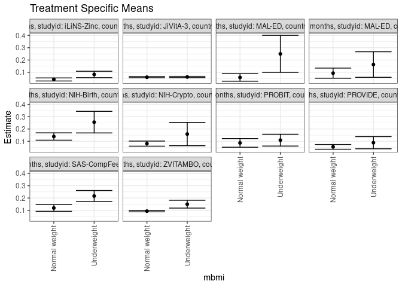

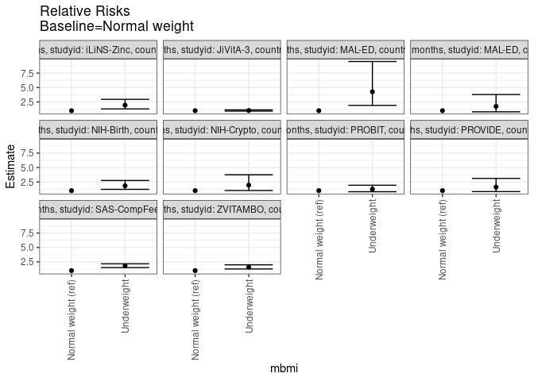

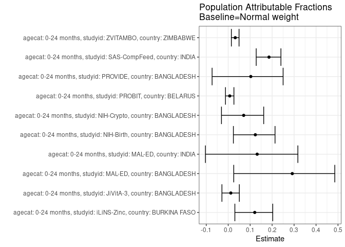

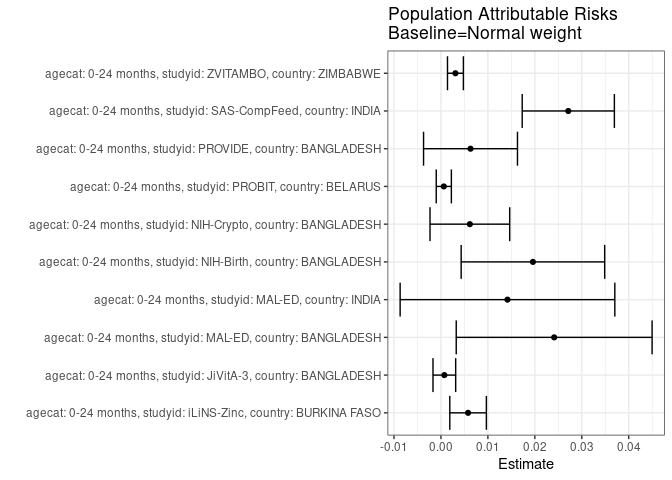

## Results Table

### Parameter: TSM

| agecat | studyid | country | intervention_level | baseline_level | estimate | ci_lower | ci_upper |
| --- | --- | --- | --- | --- | --- | --- | --- |
| 0-24 months | iLiNS-Zinc | BURKINA FASO | Normal weight | NA | 0.0420875 | 0.0295906 | 0.0545843 |
| 0-24 months | iLiNS-Zinc | BURKINA FASO | Underweight | NA | 0.0827007 | 0.0567042 | 0.1086973 |
| 0-24 months | JiVitA-3 | BANGLADESH | Normal weight | NA | 0.0602759 | 0.0561189 | 0.0644329 |
| 0-24 months | JiVitA-3 | BANGLADESH | Underweight | NA | 0.0622312 | 0.0568740 | 0.0675885 |
| 0-24 months | MAL-ED | BANGLADESH | Normal weight | NA | 0.0585586 | 0.0276115 | 0.0895057 |
| 0-24 months | MAL-ED | BANGLADESH | Underweight | NA | 0.2500000 | 0.0996753 | 0.4003247 |
| 0-24 months | MAL-ED | INDIA | Normal weight | NA | 0.0932642 | 0.0521524 | 0.1343761 |
| 0-24 months | MAL-ED | INDIA | Underweight | NA | 0.1632653 | 0.0595626 | 0.2669680 |
| 0-24 months | NIH-Birth | BANGLADESH | Normal weight | NA | 0.1390600 | 0.1092657 | 0.1688543 |
| 0-24 months | NIH-Birth | BANGLADESH | Underweight | NA | 0.2557101 | 0.1680069 | 0.3434132 |
| 0-24 months | NIH-Crypto | BANGLADESH | Normal weight | NA | 0.0812589 | 0.0605918 | 0.1019259 |
| 0-24 months | NIH-Crypto | BANGLADESH | Underweight | NA | 0.1589830 | 0.0642712 | 0.2536948 |
| 0-24 months | PROBIT | BELARUS | Normal weight | NA | 0.0871664 | 0.0519731 | 0.1223596 |
| 0-24 months | PROBIT | BELARUS | Underweight | NA | 0.1094229 | 0.0615256 | 0.1573203 |
| 0-24 months | PROVIDE | BANGLADESH | Normal weight | NA | 0.0549850 | 0.0357811 | 0.0741888 |
| 0-24 months | PROVIDE | BANGLADESH | Underweight | NA | 0.0888315 | 0.0394050 | 0.1382580 |
| 0-24 months | SAS-CompFeed | INDIA | Normal weight | NA | 0.1189156 | 0.0915960 | 0.1462352 |
| 0-24 months | SAS-CompFeed | INDIA | Underweight | NA | 0.2161177 | 0.1712921 | 0.2609432 |
| 0-24 months | ZVITAMBO | ZIMBABWE | Normal weight | NA | 0.0933687 | 0.0874436 | 0.0992939 |
| 0-24 months | ZVITAMBO | ZIMBABWE | Underweight | NA | 0.1496751 | 0.1178500 | 0.1815001 |

### Parameter: E(Y)

| agecat | studyid | country | intervention_level | baseline_level | estimate | ci_lower | ci_upper |
| --- | --- | --- | --- | --- | --- | --- | --- |
| 0-24 months | iLiNS-Zinc | BURKINA FASO | NA | NA | 0.0478707 | 0.0359037 | 0.0598376 |
| 0-24 months | JiVitA-3 | BANGLADESH | NA | NA | 0.0610001 | 0.0575046 | 0.0644957 |
| 0-24 months | MAL-ED | BANGLADESH | NA | NA | 0.0826772 | 0.0487426 | 0.1166117 |
| 0-24 months | MAL-ED | INDIA | NA | NA | 0.1074380 | 0.0683415 | 0.1465345 |
| 0-24 months | NIH-Birth | BANGLADESH | NA | NA | 0.1586538 | 0.1299648 | 0.1873429 |
| 0-24 months | NIH-Crypto | BANGLADESH | NA | NA | 0.0874172 | 0.0672569 | 0.1075775 |
| 0-24 months | PROBIT | BELARUS | NA | NA | 0.0877768 | 0.0530196 | 0.1225340 |
| 0-24 months | PROVIDE | BANGLADESH | NA | NA | 0.0612855 | 0.0430966 | 0.0794744 |
| 0-24 months | SAS-CompFeed | INDIA | NA | NA | 0.1460432 | 0.1145875 | 0.1774988 |
| 0-24 months | ZVITAMBO | ZIMBABWE | NA | NA | 0.0964581 | 0.0906120 | 0.1023042 |

### Parameter: RR

| agecat | studyid | country | intervention_level | baseline_level | estimate | ci_lower | ci_upper |
| --- | --- | --- | --- | --- | --- | --- | --- |
| 0-24 months | iLiNS-Zinc | BURKINA FASO | Normal weight | Normal weight | 1.000000 | 1.0000000 | 1.000000 |
| 0-24 months | iLiNS-Zinc | BURKINA FASO | Underweight | Normal weight | 1.964974 | 1.3039077 | 2.961193 |
| 0-24 months | JiVitA-3 | BANGLADESH | Normal weight | Normal weight | 1.000000 | 1.0000000 | 1.000000 |
| 0-24 months | JiVitA-3 | BANGLADESH | Underweight | Normal weight | 1.032439 | 0.9318725 | 1.143859 |
| 0-24 months | MAL-ED | BANGLADESH | Normal weight | Normal weight | 1.000000 | 1.0000000 | 1.000000 |
| 0-24 months | MAL-ED | BANGLADESH | Underweight | Normal weight | 4.269231 | 1.9172672 | 9.506412 |
| 0-24 months | MAL-ED | INDIA | Normal weight | Normal weight | 1.000000 | 1.0000000 | 1.000000 |
| 0-24 months | MAL-ED | INDIA | Underweight | Normal weight | 1.750567 | 0.8079836 | 3.792756 |
| 0-24 months | NIH-Birth | BANGLADESH | Normal weight | Normal weight | 1.000000 | 1.0000000 | 1.000000 |
| 0-24 months | NIH-Birth | BANGLADESH | Underweight | Normal weight | 1.838847 | 1.2273662 | 2.754972 |
| 0-24 months | NIH-Crypto | BANGLADESH | Normal weight | Normal weight | 1.000000 | 1.0000000 | 1.000000 |
| 0-24 months | NIH-Crypto | BANGLADESH | Underweight | Normal weight | 1.956501 | 1.0226337 | 3.743174 |
| 0-24 months | PROBIT | BELARUS | Normal weight | Normal weight | 1.000000 | 1.0000000 | 1.000000 |
| 0-24 months | PROBIT | BELARUS | Underweight | Normal weight | 1.255335 | 0.8147741 | 1.934113 |
| 0-24 months | PROVIDE | BANGLADESH | Normal weight | Normal weight | 1.000000 | 1.0000000 | 1.000000 |
| 0-24 months | PROVIDE | BANGLADESH | Underweight | Normal weight | 1.615560 | 0.8379439 | 3.114809 |
| 0-24 months | SAS-CompFeed | INDIA | Normal weight | Normal weight | 1.000000 | 1.0000000 | 1.000000 |
| 0-24 months | SAS-CompFeed | INDIA | Underweight | Normal weight | 1.817404 | 1.5221298 | 2.169958 |
| 0-24 months | ZVITAMBO | ZIMBABWE | Normal weight | Normal weight | 1.000000 | 1.0000000 | 1.000000 |
| 0-24 months | ZVITAMBO | ZIMBABWE | Underweight | Normal weight | 1.603053 | 1.2840307 | 2.001339 |

### Parameter: PAR

| agecat | studyid | country | intervention_level | baseline_level | estimate | ci_lower | ci_upper |
| --- | --- | --- | --- | --- | --- | --- | --- |
| 0-24 months | iLiNS-Zinc | BURKINA FASO | Normal weight | NA | 0.0057832 | 0.0018878 | 0.0096786 |
| 0-24 months | JiVitA-3 | BANGLADESH | Normal weight | NA | 0.0007242 | -0.0016921 | 0.0031405 |
| 0-24 months | MAL-ED | BANGLADESH | Normal weight | NA | 0.0241186 | 0.0032585 | 0.0449787 |
| 0-24 months | MAL-ED | INDIA | Normal weight | NA | 0.0141738 | -0.0086912 | 0.0370388 |
| 0-24 months | NIH-Birth | BANGLADESH | Normal weight | NA | 0.0195939 | 0.0043077 | 0.0348800 |
| 0-24 months | NIH-Crypto | BANGLADESH | Normal weight | NA | 0.0061584 | -0.0023285 | 0.0146452 |
| 0-24 months | PROBIT | BELARUS | Normal weight | NA | 0.0006105 | -0.0010023 | 0.0022232 |
| 0-24 months | PROVIDE | BANGLADESH | Normal weight | NA | 0.0063005 | -0.0037022 | 0.0163033 |
| 0-24 months | SAS-CompFeed | INDIA | Normal weight | NA | 0.0271276 | 0.0173109 | 0.0369442 |
| 0-24 months | ZVITAMBO | ZIMBABWE | Normal weight | NA | 0.0030894 | 0.0013959 | 0.0047828 |

### Parameter: PAF

| agecat | studyid | country | intervention_level | baseline_level | estimate | ci_lower | ci_upper |
| --- | --- | --- | --- | --- | --- | --- | --- |
| 0-24 months | iLiNS-Zinc | BURKINA FASO | Normal weight | NA | 0.1208094 | 0.0303268 | 0.2028488 |
| 0-24 months | JiVitA-3 | BANGLADESH | Normal weight | NA | 0.0118725 | -0.0285167 | 0.0506756 |
| 0-24 months | MAL-ED | BANGLADESH | Normal weight | NA | 0.2917203 | 0.0252675 | 0.4853356 |
| 0-24 months | MAL-ED | INDIA | Normal weight | NA | 0.1319251 | -0.1037369 | 0.3172702 |
| 0-24 months | NIH-Birth | BANGLADESH | Normal weight | NA | 0.1235008 | 0.0235873 | 0.2131905 |
| 0-24 months | NIH-Crypto | BANGLADESH | Normal weight | NA | 0.0704479 | -0.0306846 | 0.1616571 |
| 0-24 months | PROBIT | BELARUS | Normal weight | NA | 0.0069547 | -0.0124773 | 0.0260137 |
| 0-24 months | PROVIDE | BANGLADESH | Normal weight | NA | 0.1028065 | -0.0733564 | 0.2500570 |
| 0-24 months | SAS-CompFeed | INDIA | Normal weight | NA | 0.1857504 | 0.1275272 | 0.2400882 |
| 0-24 months | ZVITAMBO | ZIMBABWE | Normal weight | NA | 0.0320282 | 0.0143962 | 0.0493447 |